# Gencer Ates - Exam 1

```r
# don't show warnings while knitting
knitr::opts_chunk$set(warning = FALSE, message = FALSE)
```

```r
library("tm")        #processing texts and counting words
library("wordcloud")     #plotting a word cloud
library("RColorBrewer")
library("readxl")
library(sqldf)
library(vader)
library(ggplot2)
```

```r
# constants
my_working_dir_pc <- "D:\\onurg\\Documents\\MKT 326\\Exam 1" # if on a PC


myFile_yelp <- "YelpReviews.csv"
```

```r
# import data
setwd(my_working_dir_pc)
yelp <- read.csv(myFile_yelp)
```

```r
head(yelp, 20)
```

|  | Brand | ReviewId | Rating | ReviewDate | ReviewText | CoolVotes |
| --- | --- | --- | --- | --- | --- | --- |
| 1 | Dunkin | 3RaXtCUAh6rxBBiiWJ4Y0w | 5 | 11/18/16 0:00 | I don't know why people are complaining, maybe they like to complain about everything in life? I'm always I'm this drive thru, coffee's always good. | 0 |
| 2 | Dunkin | 4-5Bint9J8bOJhoVkbDgbw | 1 | 8/21/15 0:00 | This officially will be the last time that I set foot into this Dunkin! 6:43 am and they're out of most of their bagels. The donuts usually taste like their da old. \nOff to Einsteins | 0 |
| 3 | Dunkin | 49w3XwzELOognuqER2pVcg | 1 | 1/10/12 0:00 | Take the password off your free Wi-Fi or at least let people know what the password is. | 0 |
| 4 | Dunkin | 4-DUtRv7ZeAPPmBGC6XPAg | 1 | 10/21/14 0:00 | This is the second time the drive through has taken more than 20 minutes and my order is still wrong. The first time I asked for a vanilla iced coffee with cream. Instead I got iced tea mixed with cre… | 0 |
| 5 | Dunkin | 4YKsOzj4pqiu55-AFruQfw | 1 | 2/18/16 0:00 | Filthy dump. How at 9am can the trash cans be over flowing with trash and all the empty tables be dirty. The customer service needs improvement also. | 0 |
| 6 | Dunkin | 9pixSvp-nlBM8POavfMrSA | 3 | 5/30/14 0:00 | Super duper nice staff here. Plus no matter how long the line at the drive-thru is, it doesn't take long (it's overwhelming sometimes!) Today I got my usual black coffee in a Christmas cup. Either the… | 0 |
| 7 | Dunkin | a6oiovz8FsSHZDsluwISgg | 1 | 6/4/17 0:00 | Very poor trained staff ,messed up my order more than once one girl didn't know the coffee price | 0 |
| 8 | Dunkin | acsLLofnt_qrHv3ZQaLVpQ | 1 | 6/24/14 0:00 | Never been to this one before, thought I'd give it a chance but it never fails...anywhere businesses are predominately black the service is not professional or the same high standard of a more white a… | 0 |
| 9 | Dunkin | acZftgmHNSTbjbO4UybjzQ | 1 | 6/16/16 0:00 | This is not one of their better locations, I got a hand packed quart of Pralines and Cream and it had odd strange tasting chunks of ice through out the quart. My guess is that one of their employees l… | 0 |
| 10 | Dunkin | AkNOOBtvjPcLzQSG8h1lCg | 2 | 3/10/14 0:00 | now if it wasn't for the drinks an donuts we ordered being delicious, the service was extremely rude. i am on vacation from Los Angeles and was excited to try DD for my first time and was sadly disapp… | 0 |

[output cut: 10 more lines]

1. How is Dunkin doing compared to Starbucks? What is the average review ra>ng for Starbucks? For Dunkin? A[er calcula>ng the means, plot 2 histograms of review ra>ng, one for Starbucks, one for Dunkin. Finally, interpret the histograms: as a marke>ng manager for Dunkin, should you be concerned?

```r
brand_avg_ratings <- sqldf::sqldf("
      SELECT Brand, avg(Rating)
      FROM  yelp y
      GROUP BY 1

      ")
brand_avg_ratings
```

| Brand | avg(Rating) |
| --- | --- |
| Dunkin | 2.623629 |
| Starbucks | 3.121154 |

Not a good start, our average rating is lower than Starbucks, and even worse, we are below average (assuming 3 is average).

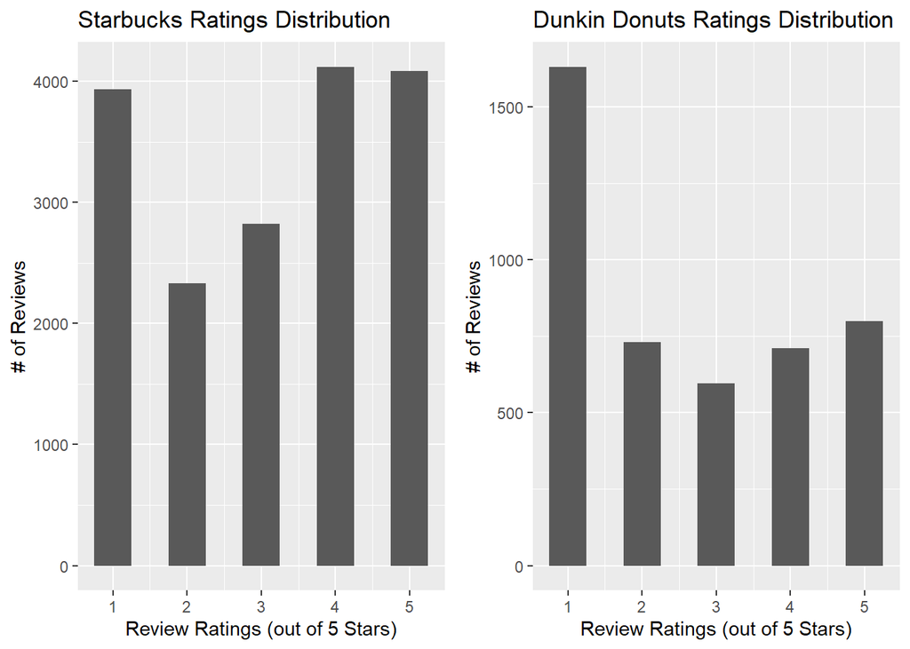

```r
sbucks_ratings <- sqldf("
      SELECT Rating
      FROM  yelp y
      WHERE Brand = 'Starbucks'
      ")

dunk_ratings <- sqldf("
      SELECT Rating
      FROM  yelp y
      WHERE Brand = 'Dunkin'
      ")

his_star <- ggplot(data = sbucks_ratings, aes(Rating)) +
  geom_histogram(binwidth = .5) +
  labs(title = "Starbucks Ratings Distribution", x = "Review Ratings (out of 5 Stars)", y = "# of Reviews")

his_dunk <- ggplot(data = dunk_ratings, aes(Rating)) +
  geom_histogram(binwidth = .5) +
  labs(title = "Dunkin Donuts Ratings Distribution", x = "Review Ratings (out of 5 Stars)", y = "# of Reviews")

library(gridExtra); library(grid)
grid.arrange(his_star, his_dunk, nrow=1, ncol=2)
```

2. Does negativity bias exist? That is, do people tend to express nega>ve experiences more so than posi>ve experiences? First, create a data column that stores the text length in characters for each review.

```r
yelp2 <- sqldf("
      SELECT *, length(ReviewText) as ReviewLen
      FROM  yelp y
      ")

head(yelp2)
```

|  | Brand | ReviewId | Rating | ReviewDate | ReviewText | CoolVotes | ReviewLen |
| --- | --- | --- | --- | --- | --- | --- | --- |
| 1 | Dunkin | 3RaXtCUAh6rxBBiiWJ4Y0w | 5 | 11/18/16 0:00 | I don't know why people are complaining, maybe they like to complain about everything in life? I'm always I'm this drive thru, coffee's always good. | 0 | 148 |
| 2 | Dunkin | 4-5Bint9J8bOJhoVkbDgbw | 1 | 8/21/15 0:00 | This officially will be the last time that I set foot into this Dunkin! 6:43 am and they're out of most of their bagels. The donuts usually taste like their da old. \nOff to Einsteins | 0 | 182 |
| 3 | Dunkin | 49w3XwzELOognuqER2pVcg | 1 | 1/10/12 0:00 | Take the password off your free Wi-Fi or at least let people know what the password is. | 0 | 87 |
| 4 | Dunkin | 4-DUtRv7ZeAPPmBGC6XPAg | 1 | 10/21/14 0:00 | This is the second time the drive through has taken more than 20 minutes and my order is still wrong. The first time I asked for a vanilla iced coffee with cream. Instead I got iced tea mixed with cre… | 0 | 471 |
| 5 | Dunkin | 4YKsOzj4pqiu55-AFruQfw | 1 | 2/18/16 0:00 | Filthy dump. How at 9am can the trash cans be over flowing with trash and all the empty tables be dirty. The customer service needs improvement also. | 0 | 149 |
| 6 | Dunkin | 9pixSvp-nlBM8POavfMrSA | 3 | 5/30/14 0:00 | Super duper nice staff here. Plus no matter how long the line at the drive-thru is, it doesn't take long (it's overwhelming sometimes!) Today I got my usual black coffee in a Christmas cup. Either the… | 0 | 745 |

Then, graph a bar chart that shows the average text length by review ra>ng. That is, the x axis is 1-, 2-, 3-, 4-, and 5-star, and the y axis is the average review length by the star ra>ng.

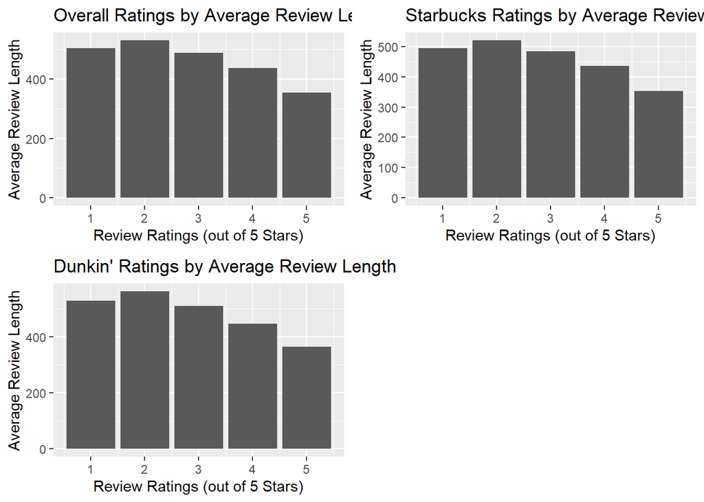

```r
yelp_overall_lenvr <- sqldf("
      SELECT Rating, AVG(ReviewLen) as AvgRevLen
      FROM  yelp2 y
      GROUP BY 1
      ")

sbucks_len <- sqldf("
      SELECT Rating, AVG(ReviewLen) as AvgRevLen
      FROM  yelp2 y
      WHERE Brand = 'Starbucks'
      GROUP BY 1
      ")

dunk_len <- sqldf("
      SELECT Rating, AVG(ReviewLen) as AvgRevLen
      FROM  yelp2 y
      WHERE Brand = 'Dunkin'
      GROUP BY 1
      ")

bar_overalllen <- ggplot(data = yelp_overall_lenvr, aes(x = Rating, y = AvgRevLen)) +
  geom_bar(stat = "identity") +
  labs(title = "Overall Ratings by Average Review Length", x = "Review Ratings (out of 5 Stars)", y = "Average Review Length")

bar_starlen <- ggplot(data = sbucks_len, aes(x = Rating, y = AvgRevLen)) +
  geom_bar(stat = "identity") +
  labs(title = "Starbucks Ratings by Average Review Length", x = "Review Ratings (out of 5 Stars)", y = "Average Review Length")

bar_dunklen <- ggplot(data = dunk_len, aes(x = Rating, y = AvgRevLen)) +
  geom_bar(stat = "identity") +
  labs(title = "Dunkin' Ratings by Average Review Length", x = "Review Ratings (out of 5 Stars)", y = "Average Review Length")

grid.arrange(bar_overalllen, bar_starlen, bar_dunklen, nrow=2, ncol=2)
```

Finally, compare the text length of 1-star reviews with that of 5-star reviews with a t test. Include the means and sta>s>cal significance in your interpreta>on writeup and answer the ques>on.

```r
t.test(yelp2[yelp2$Rating == 5, ]$ReviewLen, yelp2[yelp2$Rating == 1, ]$ReviewLen)
```

```
##
##  Welch Two Sample t-test
##
## data:  yelp2[yelp2$Rating == 5, ]$ReviewLen and yelp2[yelp2$Rating == 1, ]$ReviewLen
## t = -20.525, df = 9952.1, p-value < 2.2e-16
## alternative hypothesis: true difference in means is not equal to 0
## 95 percent confidence interval:
##  -163.6008 -135.0761
## sample estimates:
## mean of x mean of y
##  354.4719  503.8103
```

On average the bad reviews are much longer than those that are positive regardless of the brand. On average the negative ratings of 1 has the about 500 characters per review but positives have about 300-350 characters on average. This already shows there is a bias towards negative reviews. When done a hypothesis test we saw that yes high ratings don’t have a statistically similar lenghts either, alternative hypothesis: true difference in means is not equal to 0 mean of x (5 star) mean of y (1 star) 354.4719 503.8103

3. Do “cool” reviews express more posi7ve or more nega7ve sen7ments than uncool reviews? This ques>on is purposefully vague - design the analyses yourself and do them. Be sure to write down your interpreta>ons of the results and the final answer to the ques>on.

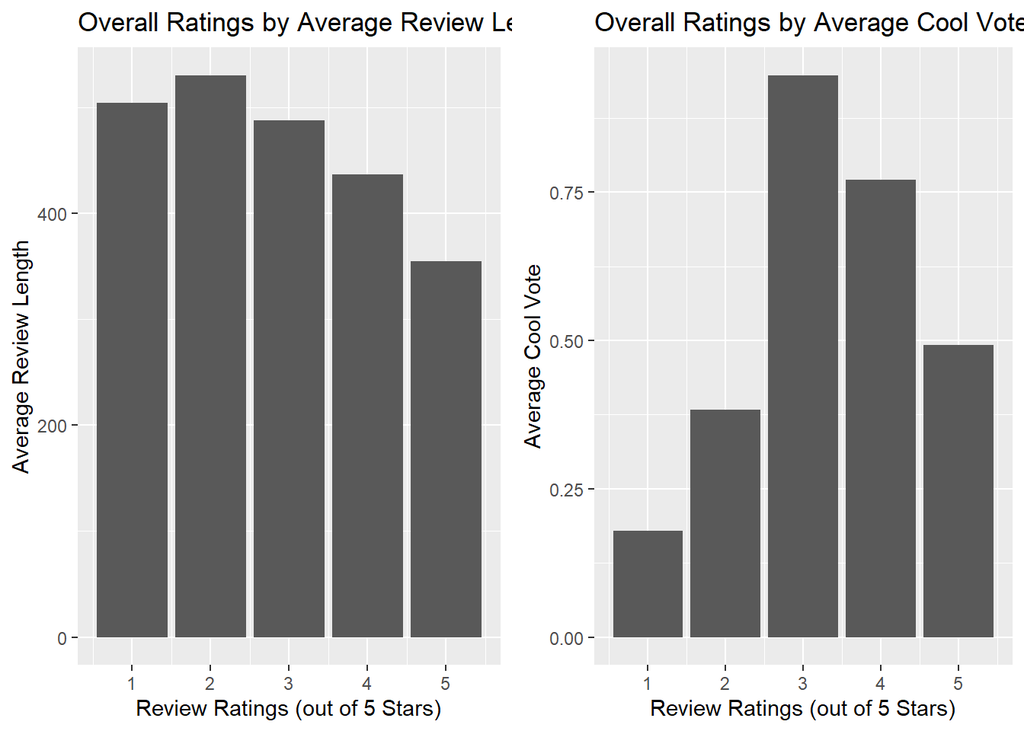

```r
cool_df <- sqldf("
      SELECT Rating, AVG(CoolVotes) avg_cool, AVG(ReviewLen) as avgrevlen
      FROM  yelp2 y
      GROUP BY 1
      ")


bar_overalllen2 <- ggplot(data = cool_df, aes(x = Rating, y = avgrevlen)) +
  geom_bar(stat = "identity") +
  labs(title = "Overall Ratings by Average Review Length", x = "Review Ratings (out of 5 Stars)", y = "Average Review Length")

bar_coolvrate <- ggplot(data = cool_df, aes(x = Rating, y = avg_cool)) +
  geom_bar(stat = "identity") +
  labs(title = "Overall Ratings by Average Cool Vote", x = "Review Ratings (out of 5 Stars)", y = "Average Cool Vote")


grid.arrange(bar_overalllen2, bar_coolvrate, nrow=1, ncol=2)
```

Do to time constraints this is as far as I go with my analysis. From the what it we can see cool cotes are more akin to neutral reviews, as in rewiews that either show both positives and negatives, or vaguely describe positives in a sub par level. Thought, I need to say, cool votes lean more towards the psotive ratings than the negative ones.